# Informe PISA - Splines - GAM

Beatriz Cárdaba

09/11/2020

**El objetivo es modelizar la relación entre la puntuación media (OSS) y el resto de variables, utilizando modelos de splines y GAM. Se debe realizar CV cuando se pueda.**

# EDA

Realizamos un análisis exploratorio de los datos para conocer sus cararterísticas.

En primer lugar conocemos las variables y los tipos de datos de contienen:

```
## tibble [65 x 11] (S3: spec_tbl_df/tbl_df/tbl/data.frame)
##  $ Country : chr [1:65] "Albania" "Argentina" "Australia" "Austria" ...
##  $ Overall : num [1:65] NA 391 527 511 382 510 390 434 534 438 ...
##  $ Issues  : num [1:65] NA 395 535 505 353 515 398 427 532 444 ...
##  $ Explain : num [1:65] NA 386 520 516 412 503 390 444 531 432 ...
##  $ Evidence: num [1:65] NA 385 531 505 344 516 378 417 542 440 ...
##  $ Interest: num [1:65] NA 567 465 507 612 503 592 523 469 591 ...
##  $ Support : num [1:65] NA 506 487 515 542 492 519 527 501 564 ...
##  $ Income  : num [1:65] 0.599 0.678 0.826 0.835 0.566 0.831 0.637 0.663 0.84 0.673 ...
##  $ Health  : num [1:65] 0.886 0.868 0.965 0.944 0.78 0.935 0.818 0.829 0.951 0.923 ...
##  $ Edu     : num [1:65] 0.716 0.786 0.978 0.824 NA 0.868 0.646 0.778 0.902 0.764 ...
##  $ HDI     : num [1:65] 0.724 0.773 0.92 0.866 NA 0.877 0.695 0.753 0.897 0.78 ...
##  - attr(*, "spec")=
##   .. cols(
##   ..   Country = col_character(),
##   ..   Overall = col_double(),
##   ..   Issues = col_double(),
##   ..   Explain = col_double(),
##   ..   Evidence = col_double(),
##   ..   Interest = col_double(),
##   ..   Support = col_double(),
##   ..   Income = col_double(),
##   ..   Health = col_double(),
##   ..   Edu = col_double(),
##   ..   HDI = col_double()
##   .. )
```

```
##  [1] "country"  "overall"  "issues"   "explain"  "evidence" "interest"
##  [7] "support"  "income"   "health"   "edu"      "hdi"
```

## Diccionario de Variables

- country: país examinado en el informe
- overall: Overall Science Score (average score for 15 year olds)
- issues:
- explain:
- evidence:
- Interest:Interest in science
- Support: Support for scientific inquiry
- income: Income Index
- health: Health Index
- edu: Education Index
- hdi: Human Development Index (composed of the Income index, Health Index, and Education Index)

## Resumen de datos

visualñizamos las caraterísticas de cada dato, en especial las medidas estadísitcas, como la media la desviación típica o los cuartiles.

```
## [1] 65 11
```

Data summary

| Name | raw_data |
| --- | --- |
| Number of rows | 65 |
| Number of columns | 11 |
| _______________________ |  |
| Column type frequency: |  |
| character | 1 |
| numeric | 10 |
| ________________________ |  |
| Group variables | None |

**Variable type: character**

| skim_variable | n_missing | complete_rate | min | max | empty | n_unique | whitespace |
| --- | --- | --- | --- | --- | --- | --- | --- |
| country | 0 | 1 | 4 | 24 | 0 | 65 | 0 |

**Variable type: numeric**

| skim_variable | n_missing | complete_rate | mean | sd | p0 | p25 | p50 | p75 | p100 | hist |
| --- | --- | --- | --- | --- | --- | --- | --- | --- | --- | --- |
| overall | 8 | 0.88 | 473.14 | 54.58 | 322.00 | 428.00 | 489.00 | 513.00 | 563.00 | ▁▃▂▇▅ |
| issues | 8 | 0.88 | 469.91 | 53.93 | 321.00 | 427.00 | 489.00 | 514.00 | 555.00 | ▁▃▂▇▆ |
| explain | 8 | 0.88 | 475.02 | 54.02 | 334.00 | 432.00 | 490.00 | 517.00 | 566.00 | ▁▃▂▇▃ |
| evidence | 8 | 0.88 | 469.81 | 61.74 | 288.00 | 423.00 | 489.00 | 515.00 | 567.00 | ▁▂▃▇▆ |
| interest | 8 | 0.88 | 528.16 | 49.84 | 448.00 | 501.00 | 522.00 | 565.00 | 644.00 | ▆▇▅▃▂ |
| support | 8 | 0.88 | 512.18 | 26.08 | 447.00 | 494.00 | 512.00 | 529.00 | 569.00 | ▂▅▇▆▂ |
| income | 4 | 0.94 | 0.74 | 0.11 | 0.41 | 0.66 | 0.76 | 0.83 | 0.94 | ▁▃▇▇▆ |
| health | 4 | 0.94 | 0.89 | 0.07 | 0.72 | 0.84 | 0.89 | 0.94 | 0.99 | ▂▂▇▆▇ |
| edu | 6 | 0.91 | 0.80 | 0.11 | 0.54 | 0.72 | 0.81 | 0.88 | 0.99 | ▂▅▆▇▅ |
| hdi | 6 | 0.91 | 0.81 | 0.09 | 0.58 | 0.75 | 0.82 | 0.88 | 0.94 | ▁▃▇▇▇ |

## Data Wrangling data

Visualizamos NA y los duplicados:

Data summary

| Name | data |
| --- | --- |
| Number of rows | 65 |
| Number of columns | 11 |
| _______________________ |  |
| Column type frequency: |  |
| character | 1 |
| numeric | 10 |
| ________________________ |  |
| Group variables | None |

**Variable type: character**

| skim_variable | n_missing | complete_rate | min | max | empty | n_unique | whitespace |
| --- | --- | --- | --- | --- | --- | --- | --- |
| country | 0 | 1 | 4 | 24 | 0 | 65 | 0 |

**Variable type: numeric**

| skim_variable | n_missing | complete_rate | mean | sd | p0 | p25 | p50 | p75 | p100 | hist |
| --- | --- | --- | --- | --- | --- | --- | --- | --- | --- | --- |
| overall | 0 | 1 | 473.14 | 51.06 | 322.00 | 436.00 | 487.00 | 511.00 | 563.00 | ▁▂▂▇▃ |
| issues | 0 | 1 | 469.91 | 50.44 | 321.00 | 431.00 | 483.00 | 509.00 | 555.00 | ▁▂▂▇▅ |
| explain | 0 | 1 | 475.02 | 50.53 | 334.00 | 441.00 | 483.00 | 516.00 | 566.00 | ▁▂▂▇▃ |
| evidence | 0 | 1 | 469.81 | 57.75 | 288.00 | 429.00 | 481.00 | 512.00 | 567.00 | ▁▂▂▇▅ |
| interest | 0 | 1 | 528.16 | 46.62 | 448.00 | 503.00 | 528.16 | 549.00 | 644.00 | ▆▇▇▃▂ |
| support | 0 | 1 | 512.18 | 24.40 | 447.00 | 497.00 | 512.18 | 527.00 | 569.00 | ▂▃▇▅▂ |
| income | 0 | 1 | 0.74 | 0.11 | 0.41 | 0.66 | 0.74 | 0.83 | 0.94 | ▁▂▆▇▅ |
| health | 0 | 1 | 0.89 | 0.06 | 0.72 | 0.84 | 0.89 | 0.94 | 0.99 | ▂▂▇▇▇ |
| edu | 0 | 1 | 0.80 | 0.11 | 0.54 | 0.74 | 0.80 | 0.87 | 0.99 | ▂▃▇▇▅ |
| hdi | 0 | 1 | 0.81 | 0.08 | 0.58 | 0.75 | 0.81 | 0.87 | 0.94 | ▁▃▆▇▆ |

## EDA

*Gráficos de dispersión:*

Representamos graficame las diferentes relaciones entre OSS (overall) y el resto de variables que indica el enunciado que son las imoortantes a tener en cuenta en este modelo:

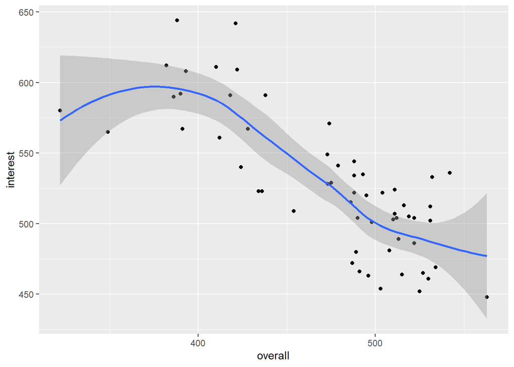

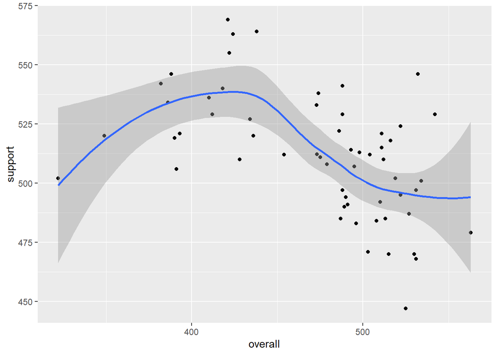

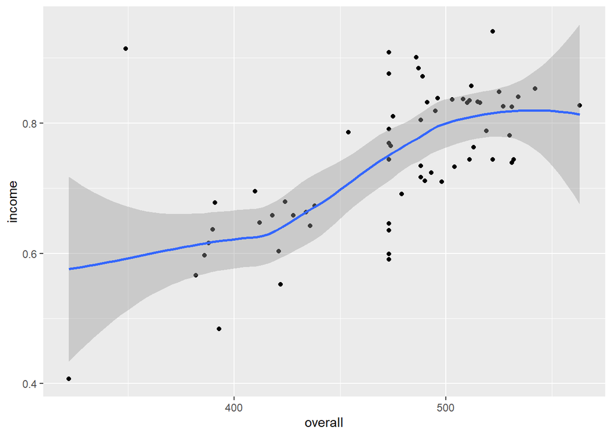

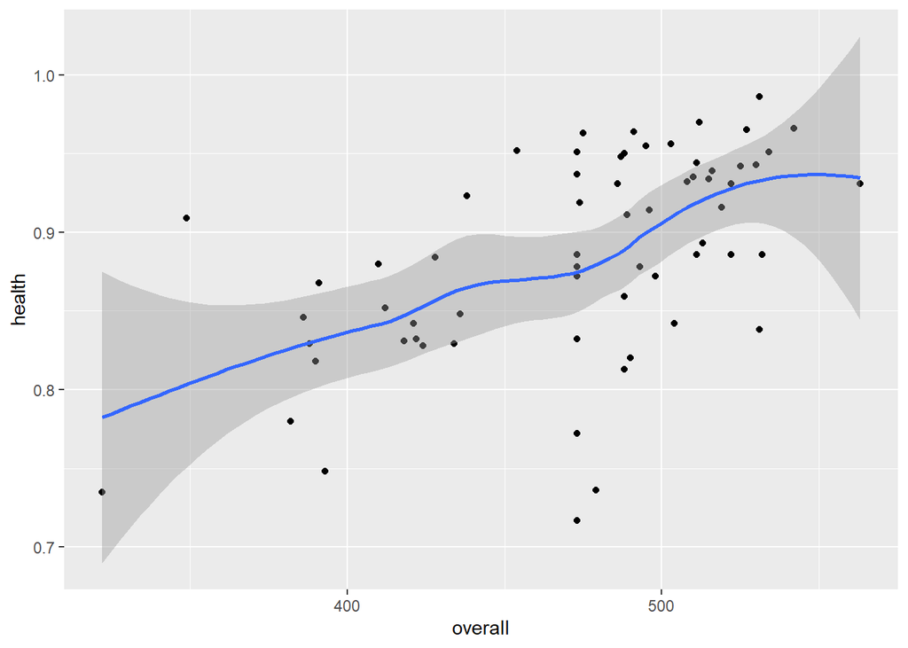

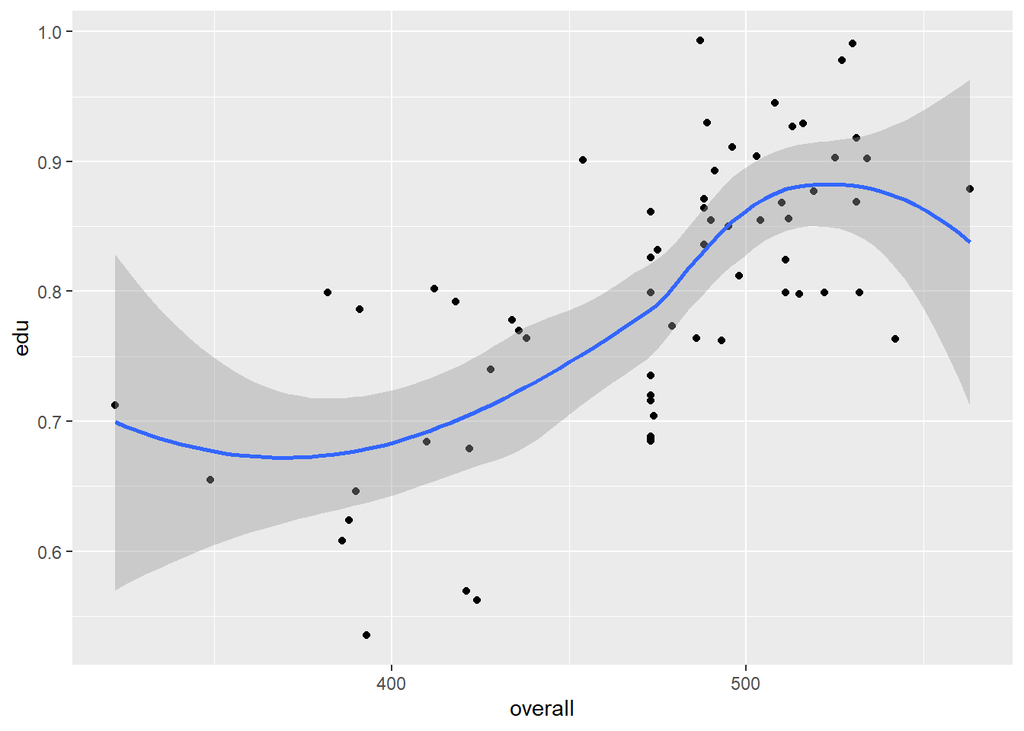

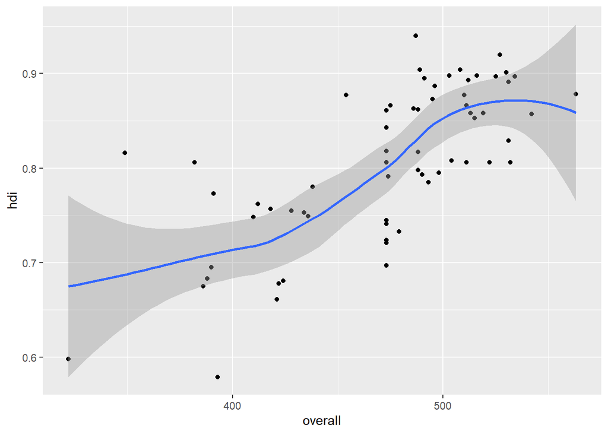

En estos gráficos podemos apreciar que las correlaciones entre las variables independientes y la variable dependiente overall no son lineales.

Vamos a comprobar como sería si se estableciera un modelo lineal:

| term | estimate | std.error | statistic | p.value |
| --- | --- | --- | --- | --- |
| (Intercept) | 451.3607224 | 146.9812323 | 3.0708732 | 3.246116e-03 |
| interest | -0.8277166 | 0.1844535 | -4.4873993 | 3.471685e-05 |
| support | 0.5866082 | 0.2620896 | 2.2381975 | 2.906203e-02 |
| income | 85.3719564 | 100.7456366 | 0.8474010 | 4.002549e-01 |
| health | 85.5721614 | 122.3637268 | 0.6993262 | 4.871434e-01 |
| edu | 114.1062627 | 118.6557023 | 0.9616585 | 3.402134e-01 |
| hdi | -89.3883002 | 254.3939621 | -0.3513774 | 7.265785e-01 |

| r.squared | adj.r.squared | sigma | statistic | p.value | df | logLik | AIC | BIC | deviance | df.residual | nobs |
| --- | --- | --- | --- | --- | --- | --- | --- | --- | --- | --- | --- |
| 0.6862607 | 0.6538049 | 30.04042 | 21.14448 | 5.677498e-13 | 6 | -309.6932 | 635.3863 | 652.7814 | 52340.77 | 58 | 65 |

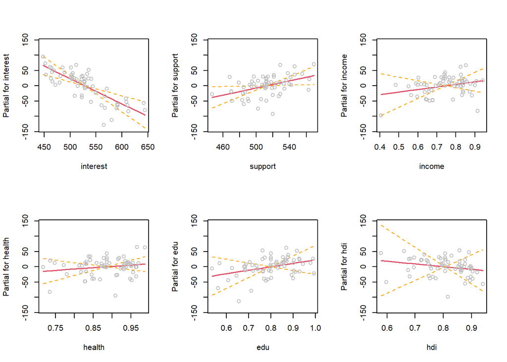

En estas gráficas nos reafirmamos en que existen relacione no lienales entre las variables del estudio.

Vamos a estudirar si esxiten correlaciones entre las variables:

*Correlación entre variables*

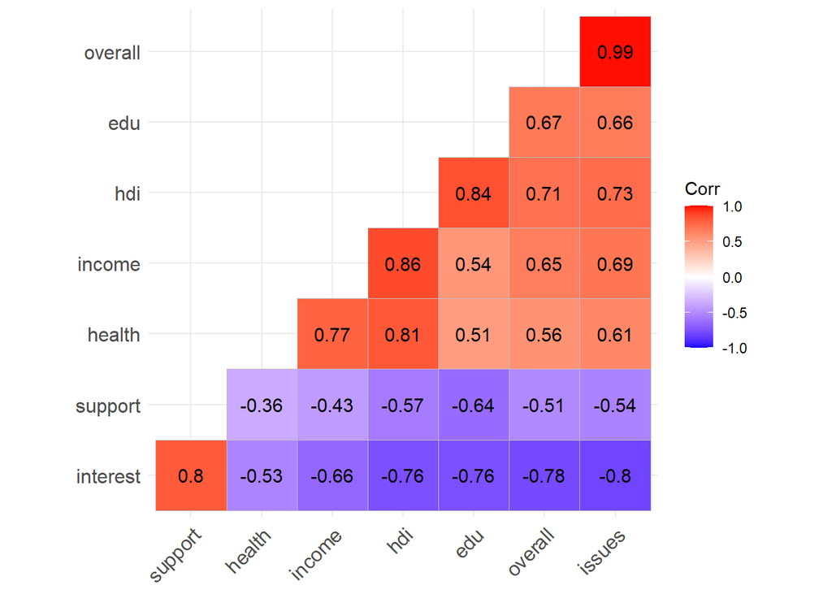

Apreciamos que existen correlaciones tanto positivas como negativas.

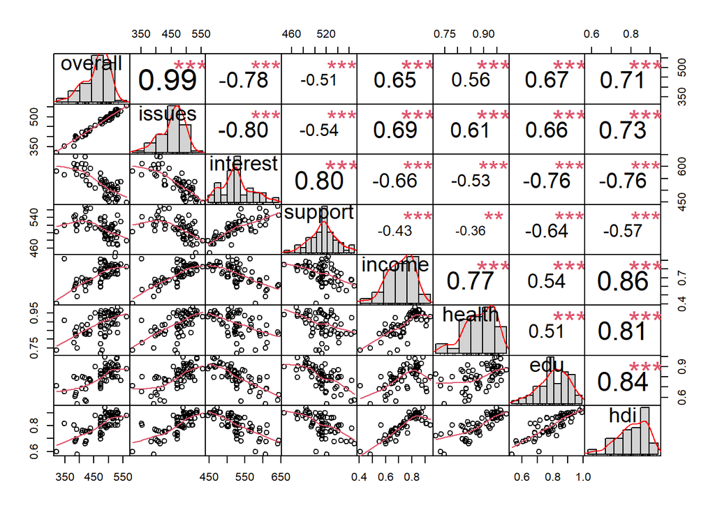

Mediante las gráficos de correlación comprobamos que las variables están correlacionas entre sí.

## Splines:

Los splines de regresión es una técnica de regresión no paramétrica. Esta técnica de regresión divide cada variable del conjunto de datos en intervalos separados por puntos llamados nudos y cada parte tiene su ajuste separado.

En los smooth splines no se tiene que elegir el número y posición de los knots, ya que hay uno en cada observación. En su lugar, se tiene que escoger un valor de λ que determine como de estricta es la penalización. Si λ = 0 el término de penalización no tiene ningún efecto, y la función estará turbia e interpolará cada valor. Si λ tiende a infinito se da el mayor suvizado posible, una línea recta.

Una forma de encontrar el λ óptimo es mediante cross-validation. Lambda controla la rugosidad de la spline suavizado, y por lo tanto los grados efectivos de libertad.

### Grados de Libertad por Cross Validation:

Calculamos los grados de libertad para cada variables para conocer el λ de cada variable:

```
## [1] 4.750171
```

```
## [1] 2.001243
```

```
## [1] 4.244952
```

```
## [1] 2.002844
```

```
## [1] 2.002385
```

```
## [1] 8.603228
```

## GAM

El modelo GAM es un modelo Aditivo por lo que podemos intrucir todas las vairables e irlas sumando con su correspondiente grado de libertad que hemos calculado mediante cross validation

En este caso todas las variables que vamos a analizar son continuas, por lo que en totdas se puede introducir el parametro “s” para que se smooth

```
##
## Call: gam(formula = overall ~ s(interest, 4.750171) + s(support, 2.001243) +
##     s(income, 4.244952) + s(health, 2.002844) + s(edu, 2.002385) +
##     s(hdi, 8.603228), data = data)
## Deviance Residuals:
##     Min      1Q  Median      3Q     Max
## -60.474  -8.204   3.146  11.663  51.433
##
## (Dispersion Parameter for gaussian family taken to be 596.1798)
##
##     Null Deviance: 166828.9 on 64 degrees of freedom
## Residual Deviance: 24082.78 on 40.3952 degrees of freedom
## AIC: 620.1379
##
## Number of Local Scoring Iterations: NA
##
## Anova for Parametric Effects
##                           Df Sum Sq Mean Sq  F value   Pr(>F)
## s(interest, 4.750171)  1.000  90386   90386 151.6092 2.96e-15 ***
## s(support, 2.001243)   1.000   2922    2922   4.9011  0.03255 *
## s(income, 4.244952)    1.000   4153    4153   6.9665  0.01174 *
## s(health, 2.002844)    1.000    743     743   1.2458  0.27095
## s(edu, 2.002385)       1.000    341     341   0.5713  0.45413
## s(hdi, 8.603228)       1.000   3326    3326   5.5795  0.02308 *
## Residuals             40.395  24083     596
## ---
## Signif. codes:  0 '***' 0.001 '**' 0.01 '*' 0.05 '.' 0.1 ' ' 1
##
## Anova for Nonparametric Effects
##                       Npar Df Npar F   Pr(F)
## (Intercept)
## s(interest, 4.750171)     3.8 3.3651 0.02010 *
## s(support, 2.001243)      1.0 1.6195 0.21046
## s(income, 4.244952)       3.2 6.2325 0.00109 **
## s(health, 2.002844)       1.0 1.4044 0.24301
## s(edu, 2.002385)          1.0 1.7024 0.19939
## s(hdi, 8.603228)          7.6 1.2305 0.30759
## ---
## Signif. codes:  0 '***' 0.001 '**' 0.01 '*' 0.05 '.' 0.1 ' ' 1
```

Representamos graficamente la salidad para la regresión GAM:

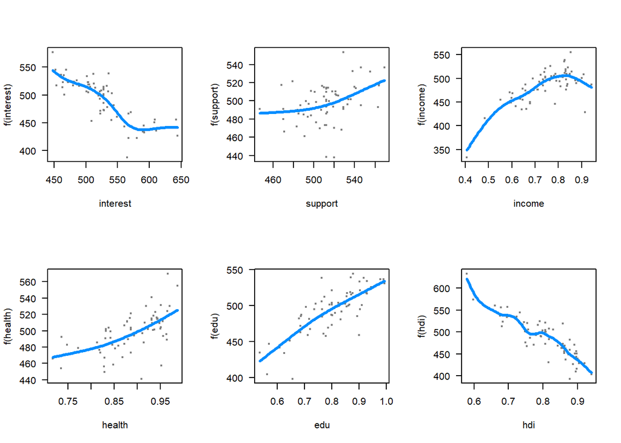

De la salida observamos que no son significativas las variables health y education en los efectos parametricos por lo que quitamos el efecto smooth

```
##
## Call: gam(formula = overall ~ s(interest, 4.750171) + s(support, 2.001243) +
##     s(income, 4.244952) + (health) + (edu) + s(hdi, 8.603228),
##     data = data)
## Deviance Residuals:
##     Min      1Q  Median      3Q     Max
## -63.473  -8.509   2.416  10.923  54.537
##
## (Dispersion Parameter for gaussian family taken to be 594.8424)
##
##     Null Deviance: 166828.9 on 64 degrees of freedom
## Residual Deviance: 25221.61 on 42.4005 degrees of freedom
## AIC: 619.1305
##
## Number of Local Scoring Iterations: NA
##
## Anova for Parametric Effects
##                         Df Sum Sq Mean Sq  F value    Pr(>F)
## s(interest, 4.750171)  1.0  91037   91037 153.0443 1.166e-15 ***
## s(support, 2.001243)   1.0   2729    2729   4.5884   0.03798 *
## s(income, 4.244952)    1.0   4320    4320   7.2630   0.01005 *
## health                 1.0    744     744   1.2505   0.26976
## edu                    1.0    575     575   0.9663   0.33119
## s(hdi, 8.603228)       1.0   3109    3109   5.2259   0.02731 *
## Residuals             42.4  25222     595
## ---
## Signif. codes:  0 '***' 0.001 '**' 0.01 '*' 0.05 '.' 0.1 ' ' 1
##
## Anova for Nonparametric Effects
##                       Npar Df Npar F    Pr(F)
## (Intercept)
## s(interest, 4.750171)     3.8 3.4267 0.018132 *
## s(support, 2.001243)      1.0 1.7051 0.198674
## s(income, 4.244952)       3.2 4.9403 0.004083 **
## health
## edu
## s(hdi, 8.603228)          7.6 1.3238 0.260089
## ---
## Signif. codes:  0 '***' 0.001 '**' 0.01 '*' 0.05 '.' 0.1 ' ' 1
```

Representamos graficamente el modelo GAM 2

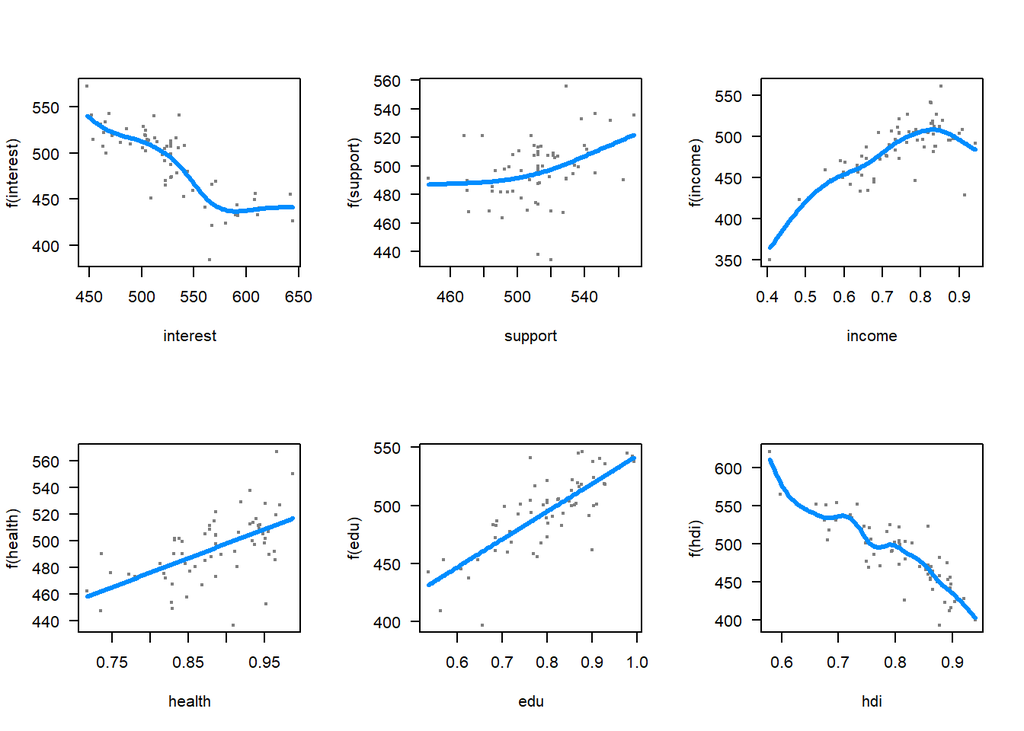

De la salida podemos observar que tanto el AIC como el error disminuyen levemente en GAM 2.